# (Determinants of ProsperScore)

## by (Awofolaju Afusat)

## Investigation Overview

> The main goal is to determine if some independent variables(EmploymentStatus, IncomeVerifiable, OnTimeProsperPayments, IsBorrowerHomeowner and Recommendations) i chose will affect/influence the dependent variable(ProsperScore).

> The key insights for the presentation will be distribution of ProsperScore to check which ProsperScore has the highest count, how employment status, income verifiable affects prosperScore. Also, i would like to check how being a home owner and getting recommendations influence the dependent variable (ProsperScore).

## Dataset Overview

> The dataset used for the analysis is a loan dataset from Prosper which consists of 113,937 loans with 81 variables on each loan, including loan amount, borrower rate (or interest rate), current loan status, borrower income, and many others.

## Plot Distribution of ProsperScore

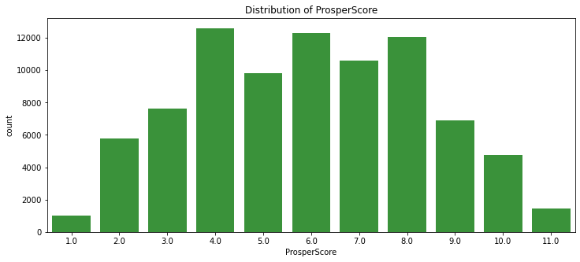

## Plot Distribution of IncomeVerifiable

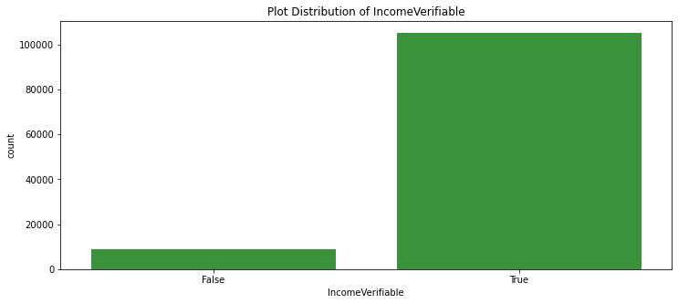

## IsBorrowerHomeowner vs ProsperScore

It can be seen from the graph below that the ProsperScore of borrowers who are home owners is higher than those who are not.

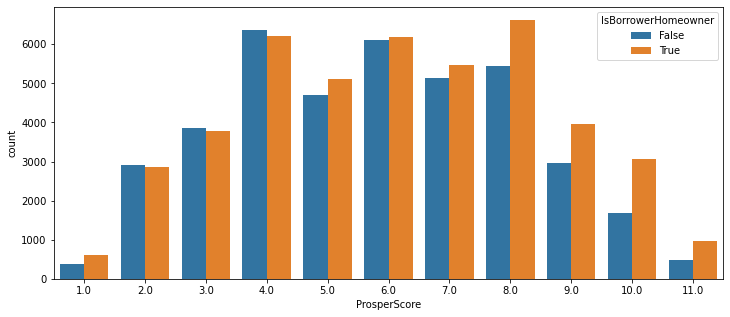